# House price prediction

```r
require(dplyr)
require(ggplot2)
require(tidyr)
require(scales)
require(caret)
train <- read.csv('../data/train.csv')
test <- read.csv('../data/test.csv')

cat('dimensions: ', dim(train))
```

```
dimensions:  1460 81
```

```r
head(train)
```

```
  Id MSSubClass MSZoning LotFrontage LotArea Street Alley LotShape
1  1         60       RL          65    8450   Pave  <NA>      Reg
2  2         20       RL          80    9600   Pave  <NA>      Reg
3  3         60       RL          68   11250   Pave  <NA>      IR1
4  4         70       RL          60    9550   Pave  <NA>      IR1
5  5         60       RL          84   14260   Pave  <NA>      IR1
6  6         50       RL          85   14115   Pave  <NA>      IR1
  LandContour Utilities LotConfig LandSlope Neighborhood Condition1
1         Lvl    AllPub    Inside       Gtl      CollgCr       Norm
2         Lvl    AllPub       FR2       Gtl      Veenker      Feedr
3         Lvl    AllPub    Inside       Gtl      CollgCr       Norm
4         Lvl    AllPub    Corner       Gtl      Crawfor       Norm
5         Lvl    AllPub       FR2       Gtl      NoRidge       Norm
6         Lvl    AllPub    Inside       Gtl      Mitchel       Norm
  Condition2 BldgType HouseStyle OverallQual OverallCond YearBuilt
```

[output cut: 76 more lines]

note: this looks different for the training-set

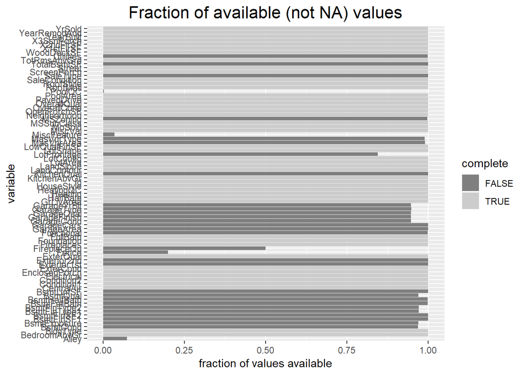

```r
fraction_available <- sapply(test, function(col) 1 - mean(is.na(col)))
available_values <- data.frame(fraction_available)
available_values['variable'] <- row.names(available_values)
row.names(available_values) <- NULL
available_values['complete'] <- as.factor(available_values$fraction_available == 1)

ggplot(available_values, aes(x=variable, y=fraction_available, fill=complete) ) +
  geom_bar( stat='identity' ) +
  coord_flip() +
  scale_fill_manual(values=c('gray50', 'gray80')) +
  ylab('fraction of values available') +
  ggtitle('Fraction of available (not NA) values') +
  theme(plot.title=element_text(size=16, hjust=0.5))
```

## pre-process

We have to make sure that a feature is complete in both, training- and test-set. Otherwise it’s of no use. Therefore, the fraction of available values (not NA values) is calculated for both. And used as information for the function ‘impute_na’ from ‘pre_process.R’

```r
source('pre_process.R')

na_statsistics <- get_na_stats(train_df=train, test_df=test)
head(na_statsistics)
```

```
##      variable available_test available_train available_min complete
## 1          Id      1.0000000       1.0000000     1.0000000     TRUE
## 2  MSSubClass      1.0000000       1.0000000     1.0000000     TRUE
## 3    MSZoning      0.9972584       1.0000000     0.9972584    FALSE
## 4 LotFrontage      0.8444140       0.8226027     0.8226027    FALSE
## 5     LotArea      1.0000000       1.0000000     1.0000000     TRUE
## 6      Street      1.0000000       1.0000000     1.0000000     TRUE
```

If the fraction of NA-values exceeds 10% in either training- or test-set, the feature is dropped for now. If a fraction of less than 10% is NA, the NA-values are imputed. For factors, a new factor level ‘NA’ is made. This just means that ‘unknown’ becomes it’s own dummy variable. For numerical values, the NA-values are replaced with the median of the feature.

**Feature engineering:** All features are either factor or numeric (has been checked). Some features with datatype ‘numeric’ are ordinal and it makes more sense to encode them as factor. If a feature has datatype numeric but only a few distinct values, that’s a sign that it should maybe be used as a factor.

The test-set has no target-variable. It can be used for evaluation on kaggle but here in R we cannot evaluate the predictions on this test-set.

**Note**: Fixed bug: previously, the model was trained on the whole labelled dataset (train.csv) and evaluated on the validation set which is a part of this dataset. That’s why the problem with rare factor levels did not occur (see function ‘remove_rare_factor_levles’ in ‘pre_process.R’).

## Modelling

…warning maybe because of multicolinearity

```r
train_processed <- pre_process_data(train)  # here columns with only a few NAs are imputed (not thrown away)

split_data <- split_training_validation_ds(train_processed, validation_fraction=0.2)
train <- split_data[[1]]
val <- split_data[[2]]
```

use somewhat pre-processed data (features with more than 10% NA removed, featrues with very few NAs imputed, some feature engineering). Then build a model using all features.

```r
naive_model <- lm(data=train, SalePrice ~ . )

val['prediction'] <- predict(naive_model, newdata=val)
```

```
## Warning in predict.lm(naive_model, newdata = val): prediction from a rank-
## deficient fit may be misleading
```

```r
val['residual'] <- abs(val$SalePrice - val$prediction)
val %>% select(SalePrice, prediction) %>% head()
```

```
##     SalePrice prediction
## 966    178900   181260.5
## 532    128000   141705.0
## 23     230000   207203.1
## 402    164990   207582.0
## 627    139900   119798.5
## 433    122500   119159.0
```

```r
mad <- mean(val$residual)  # mean absolute eviation
cat(sprintf('MAD: %s\nmean sale-price: %s', round(mean(val$residual)), round(mean(val$SalePrice))))
```

```
## MAD: 20000
## mean sale-price: 181238
```

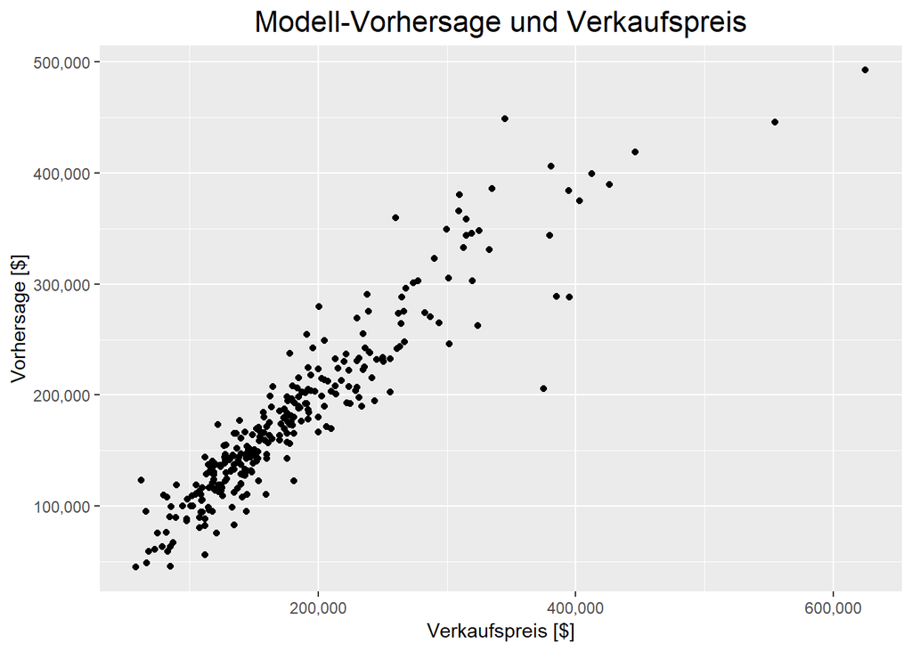

```r
ggplot(val, aes(x=SalePrice, y=prediction) ) +
  geom_point() +
  scale_x_continuous(labels = scales::comma) +
  scale_y_continuous(labels = scales::comma) +
  ylab('Vorhersage [$]') +
  xlab('Verkaufspreis [$]') +
  ggtitle('Modell-Vorhersage und Verkaufspreis') +
  theme(plot.title=element_text(size=16, hjust=0.5))
```

```r
ggsave('../talk/figures/simple_model.pdf')
```

============================================================================================================================================

## Identifizieren der Variablen mit den größten Effekten mit Hilfe von standardisierten Koeffizienten

## Nachteil unstandardisierter Regressionskoeffizienten:

Der Regressionskoeffizient gibt an, um wie viele Einheiten sich Y im Durchschnitt ?ndert, wenn X sich um eine absolute Einheit ?ndert. Deshalb ist der Regressionskoeffizient selbst von den Ma?einheiten von X und Y abh?ngig und daher schlechter vergleichbar.

## Ausweg: Standardisierte Koeffizienten (sog. “Beta-Koeffizienten”)

$\hat{\beta_i} = \beta_i*\frac{s_{x_i}}{s_y}$

$\beta_i$ = unstandardisierter Regressionkoeffizient

$s_{x_i}$ = Standardabweichung der unabh?ngigen Varibalbe $X_i$

$s_y$ = Standardabweichung der abh?ngigen Variable Y

Vorteil: $\hat{\beta_i}$ liegt idealerweise im Intervall [-1,1] (sonst Hinweis auf Mulitkollinearität) und kann daher sowohl der Richtung als auch der Stärke nach eindeutig interpretiert werden.

Nachteil: Eignet sich nur für Variablen, bei denen die Standardabweichung sinnvoll interpretiert werden kann und nicht für den Vergleich verschiedener Stichproben

```r
stand_model <- lm(data=train_processed, scale(SalePrice) ~ 0 + scale(LotArea) + scale(YearRemodAdd) + scale(MasVnrArea) + scale(X1stFlrSF) + scale(X2ndFlrSF) + scale(GarageArea) + scale(WoodDeckSF) + scale(ScreenPorch) + scale(OverallQual))

summary(stand_model)
```

```
##
## Call:
## lm(formula = scale(SalePrice) ~ 0 + scale(LotArea) + scale(YearRemodAdd) +
##     scale(MasVnrArea) + scale(X1stFlrSF) + scale(X2ndFlrSF) +
##     scale(GarageArea) + scale(WoodDeckSF) + scale(ScreenPorch) +
##     scale(OverallQual), data = train_processed)
##
## Residuals:
##     Min      1Q  Median      3Q     Max
## -5.8579 -0.2341 -0.0194  0.1944  3.9476
##
## Coefficients:
##                     Estimate Std. Error t value Pr(>|t|)
## scale(LotArea)       0.07608    0.01317   5.775 9.40e-09 ***
## scale(YearRemodAdd)  0.11680    0.01501   7.781 1.36e-14 ***
## scale(MasVnrArea)    0.08857    0.01401   6.322 3.44e-10 ***
## scale(X1stFlrSF)     0.30084    0.01734  17.352  < 2e-16 ***
## scale(X2ndFlrSF)     0.20406    0.01455  14.025  < 2e-16 ***
## scale(GarageArea)    0.11991    0.01598   7.504 1.07e-13 ***
## scale(WoodDeckSF)    0.06608    0.01308   5.051 4.96e-07 ***
## scale(ScreenPorch)   0.04543    0.01248   3.640 0.000282 ***
## scale(OverallQual)   0.39285    0.01896  20.718  < 2e-16 ***
## ---
## Signif. codes:  0 '***' 0.001 '**' 0.01 '*' 0.05 '.' 0.1 ' ' 1
##
## Residual standard error: 0.4697 on 1451 degrees of freedom
## Multiple R-squared:  0.7806, Adjusted R-squared:  0.7792
## F-statistic: 573.5 on 9 and 1451 DF,  p-value: < 2.2e-16
```